# Transcriptomics Exam

Sara Ometto

2022-07-08

# Bulk analysis

The goal is performing a bulk-RNAseq analysis across 3 different tissue samples to detect differentially expressed genes. The tissue used are: Brain, Liver and Colon

Loading the library needed for the analysis

```r
library(recount3)
library(edgeR)
library(ggplot2)
library(dplyr)
library(tidyr)
library(reshape)
library(ggpubr)
library(reshape2)
library(ggrepel)
```

## Loading the data

First load the dataset and select three replicates per tissue, discarding the samples not satisfying the quality parameters.

```r
rse_brain <- readRDS("rse_brain.RDS")
rse_liver <- readRDS("rse_liver.RDS")
rse_colon <- readRDS("rse_colon.RDS")
```

Transform the counts from read coverage over exons in read counts.

```r
assays(rse_brain)$counts <- transform_counts(rse_brain)
assays(rse_liver)$counts <- transform_counts(rse_liver)
assays(rse_colon)$counts <- transform_counts(rse_colon)
```

## Quality control

The repicates are chosen according to RIN (> 6), fraction of reads of rRNA ( < 0.1) and % uniquely mapped reads ( > 85%).

### Brain

```r
for (id in c(11, 12, 13)){
  cat('Sample n°', id, '\n')
  cat('RIN:', colData(rse_brain)$gtex.smrin[id], '\n')
  cat('rRNA:', colData(rse_brain)$gtex.smrrnart[id], '\n')
  cat('Mapping:', colData(rse_brain)$"recount_qc.star.uniquely_mapped_reads_%_both"[id], '\n\n')}
```

```
## Sample n° 11
## RIN: 6.4
## rRNA: 0.0654561
## Mapping: 89
##
## Sample n° 12
## RIN: 7.5
## rRNA: 0.0152067
## Mapping: 91.3
##
## Sample n° 13
## RIN: 7.1
## rRNA: 0.0527296
## Mapping: 89.8
```

### Liver

```r
for (id in c(11, 12, 14)){
  cat('Sample n°', id, '\n')
  cat('RIN:', colData(rse_liver)$gtex.smrin[id], '\n')
  cat('rRNA:', colData(rse_liver)$gtex.smrrnart[id], '\n')
  cat('Mapping:', colData(rse_liver)$"recount_qc.star.uniquely_mapped_reads_%_both"[id], '\n\n')}
```

```
## Sample n° 11
## RIN: 8.2
## rRNA: 0.00923495
## Mapping: 89.1
##
## Sample n° 12
## RIN: 8.5
## rRNA: 0.00909413
## Mapping: 90.7
##
## Sample n° 14
## RIN: 7.3
## rRNA: 0.00714291
## Mapping: 89.2
```

### Colon

```r
for (id in c(10, 11, 15)){
  cat('Sample n°', id, '\n')
  cat('RIN:', colData(rse_colon)$gtex.smrin[id], '\n')
  cat('rRNA:', colData(rse_colon)$gtex.smrrnart[id], '\n')
  cat('Mapping:', colData(rse_colon)$"recount_qc.star.uniquely_mapped_reads_%_both"[id], '\n\n')}
```

```
## Sample n° 10
## RIN: 7.4
## rRNA: 0.00545723
## Mapping: 91.9
##
## Sample n° 11
## RIN: 8
## rRNA: 0.00681986
## Mapping: 87.3
##
## Sample n° 15
## RIN: 8.2
## rRNA: 0.0145463
## Mapping: 87.4
```

## Selecting the replicates

```r
rse_brain_selected <- rse_brain[, c(11,12,13)]
rse_liver_selected <- rse_liver[, c(11,12,14)]
rse_colon_selected <- rse_colon[, c(10,11,15)]
```

Extract the counts for each of the replicate

```r
counts_brain_selected <- assays(rse_brain_selected)$counts
counts_liver_selected <- assays(rse_liver_selected)$counts
counts_colon_selected <- assays(rse_colon_selected)$counts

#give the official gene name:
rownames(counts_brain_selected) <- rowData(rse_brain)$gene_name
rownames(counts_liver_selected) <- rowData(rse_liver)$gene_name
rownames(counts_colon_selected) <- rowData(rse_colon)$gene_name
```

## Count Table

Build the count table and assign the official gene name. A “DE gene” object is defined, containing all the info about the dataset.

```r
count_table <- cbind(counts_brain_selected, counts_liver_selected, counts_colon_selected)
colnames(count_table) <- c("Brain11", "Brain12", "Brain13", "Liver11", "Liver12", "Liver14", "Colon10", "Colon11", "Colon15")

y <- DGEList(counts=count_table)
```

Label the samples according to the tissue and add this information to the result object (y):

```r
group <- as.factor(c('Brain', 'Brain', 'Brain', 'Liver', 'Liver', 'Liver', 'Colon', 'Colon', 'Colon'))

y$samples$group <- group
```

‘Quality’ information can be added to the result object for each sample:

```r
# RIN = RNA integrity number
y$samples$rin <- as.factor(c(
  colData(rse_brain_selected)$gtex.smrin,
  colData(rse_liver_selected)$gtex.smrin,
  colData(rse_colon_selected)$gtex.smrin))

# rRNA
y$samples$rRNA <- as.factor(c(
  colData(rse_brain_selected)$gtex.smrrnart,
  colData(rse_liver_selected)$gtex.smrrnart,
  colData(rse_colon_selected)$gtex.smrrnart))

# % of uniquely mapped reads
y$samples$mapped <- as.factor(c(
  colData(rse_brain_selected)$'recount_qc.star.uniquely_mapped_reads_%_both',
  colData(rse_liver_selected)$'recount_qc.star.uniquely_mapped_reads_%_both',
  colData(rse_colon_selected)$'recount_qc.star.uniquely_mapped_reads_%_both'))

# % of reads mapping on the mitochondrial chromosome
y$samples$chrM <- as.factor(c(
  colData(rse_brain_selected)$'recount_qc.aligned_reads%.chrm',
  colData(rse_liver_selected)$'recount_qc.aligned_reads%.chrm',
  colData(rse_colon_selected)$'recount_qc.aligned_reads%.chrm'))

# SLICE - tissue provenence
y$samples$slice <- as.factor(c(
  colData(rse_brain_selected)$gtex.smtsd,
  colData(rse_liver_selected)$gtex.smtsd,
  colData(rse_colon_selected)$gtex.smtsd))

# Sex
y$samples$sex <- as.factor(c(
  colData(rse_brain_selected)$gtex.sex,
  colData(rse_liver_selected)$gtex.sex,
  colData(rse_colon_selected)$gtex.sex))

# Age
y$samples$age <- as.factor(c(
  colData(rse_brain_selected)$gtex.age,
  colData(rse_liver_selected)$gtex.age,
  colData(rse_colon_selected)$gtex.age))

y
```

```
## An object of class "DGEList"
## $counts
##              Brain11 Brain12 Brain13 Liver11 Liver12 Liver14 Colon10 Colon11
## SNX18P15           0       0       0       0       0       0       0       0
## SNX18P16           0       0       0       0       0       0       0       0
## ANKRD20A12P        0       0       0       0       0       0       0       0
## ANKRD20A15P        0       0       0       0       0       0       0       0
## LOC105379272       0       0       0       0       0       0       0       0
##              Colon15
## SNX18P15           0
## SNX18P16           0
## ANKRD20A12P        0
## ANKRD20A15P        0
## LOC105379272       0
## 54037 more rows ...
##
## $samples
##         group lib.size norm.factors rin       rRNA mapped  chrM
## Brain11 Brain 25327468            1 6.4  0.0654561     89 28.16
## Brain12 Brain 32538624            1 7.5  0.0152067   91.3  7.62
## Brain13 Brain 29674279            1 7.1  0.0527296   89.8 19.75
## Liver11 Liver 30763889            1 8.2 0.00923495   89.1 10.67
## Liver12 Liver 33297387            1 8.5 0.00909413   90.7  9.51
## Liver14 Liver 33834950            1 7.3 0.00714291   89.2  8.18
## Colon10 Colon 32134980            1 7.4 0.00545723   91.9  9.41
## Colon11 Colon 29396396            1   8 0.00681986   87.3 13.53
## Colon15 Colon 25703372            1 8.2  0.0145463   87.4 21.11
##                                            slice sex   age
## Brain11 Brain - Anterior cingulate cortex (BA24)   1 60-69
## Brain12       Brain - Spinal cord (cervical c-1)   1 60-69
## Brain13                 Brain - Substantia nigra   1 50-59
## Liver11                                    Liver   2 40-49
## Liver12                                    Liver   1 50-59
## Liver14                                    Liver   1 20-29
## Colon10                          Colon - Sigmoid   1 60-69
## Colon11                       Colon - Transverse   1 40-49
## Colon15                       Colon - Transverse   1 60-69
```

Check how many genes have 0 counts

```r
table(rowSums(y$counts == 0) == 9)
```

```
##
## FALSE  TRUE
## 39580 14462
```

## Filtering by expression

Remove all genes with expression zero or “quasi zero”

```r
keep.expressed <- filterByExpr(y, group = group)
y <- y [keep.expressed, , keep.lib.sizes = F]
```

## Normalization

Before normalization extract and store in a vector the log of the counts per million. Then transform the counts in Counts Per Million in a Logarithmich scale (logCPM)

```r
logcpm_before <- cpm(y, log = T)

y <- calcNormFactors(y, method = 'TMM')
head(y)
```

```
## An object of class "DGEList"
## $counts
##              Brain11 Brain12 Brain13 Liver11 Liver12 Liver14 Colon10 Colon11
## MIR6859-1         13      20      10      15       9       9      16      18
## WASH7P          1233    1293     845     616     424     502     975    1096
## SEPT14P18          9      22      29      20      20      24      23      14
## CICP27             6       7       8      12       5      11       6       6
## LOC729737        440     639    1388     561     254     987    1011     225
## LOC102725121       5      11      15       8       1       4      16      10
##              Colon15
## MIR6859-1         13
## WASH7P           922
## SEPT14P18         15
## CICP27            12
## LOC729737        890
## LOC102725121      22
##
## $samples
##         group lib.size norm.factors rin       rRNA mapped  chrM
## Brain11 Brain 25268885    1.1368646 6.4  0.0654561     89 28.16
## Brain12 Brain 32494317    1.0752232 7.5  0.0152067   91.3  7.62
## Brain13 Brain 29619492    1.2712076 7.1  0.0527296   89.8 19.75
## Liver11 Liver 30730465    0.7955956 8.2 0.00923495   89.1 10.67
## Liver12 Liver 33267873    0.6066966 8.5 0.00909413   90.7  9.51
## Liver14 Liver 33819794    0.5523019 7.3 0.00714291   89.2  8.18
## Colon10 Colon 32095204    1.2266196 7.4 0.00545723   91.9  9.41
## Colon11 Colon 29212532    1.4841047   8 0.00681986   87.3 13.53
## Colon15 Colon 25494327    1.3260541 8.2  0.0145463   87.4 21.11
##                                            slice sex   age
## Brain11 Brain - Anterior cingulate cortex (BA24)   1 60-69
## Brain12       Brain - Spinal cord (cervical c-1)   1 60-69
## Brain13                 Brain - Substantia nigra   1 50-59
## Liver11                                    Liver   2 40-49
## Liver12                                    Liver   1 50-59
## Liver14                                    Liver   1 20-29
## Colon10                          Colon - Sigmoid   1 60-69
## Colon11                       Colon - Transverse   1 40-49
## Colon15                       Colon - Transverse   1 60-69
```

```r
y$samples$norm.factors
```

```
## [1] 1.1368646 1.0752232 1.2712076 0.7955956 0.6066966 0.5523019 1.2266196
## [8] 1.4841047 1.3260541
```

```r
logcpm <- cpm(y, log = T)
logcpm_after <- logcpm
```

Visualize the normalization applied to the logCPM using box-plots

Graph of logCPM before normalization

```r
brain <- c("Brain11", "Brain12", "Brain13")
liver <- c("Liver11", "Liver12", "Liver14")
colon <- c("Colon10", "Colon11", "Colon15")

logcpm_before_long <- data.frame(logcpm_before)
#pivot the data frame into a long format

logcpm_before_long$GeneID <- rownames(logcpm_before_long)
names <- colnames(logcpm_before_long)[1: length(colnames(logcpm_before_long)) - 1]

logcpm_before_long  <- logcpm_before_long  %>% pivot_longer(cols= names ,
                    names_to= 'Samples',
                    values_to='counts')
```

```
## Note: Using an external vector in selections is ambiguous.
## ℹ Use `all_of(names)` instead of `names` to silence this message.
## ℹ See <https://tidyselect.r-lib.org/reference/faq-external-vector.html>.
```

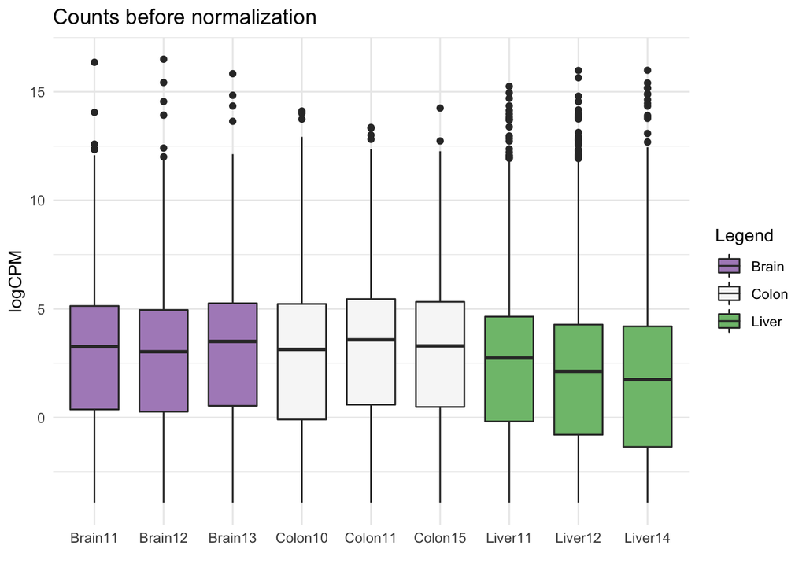

```r
logcpm_before_long$Legend <- ifelse(logcpm_before_long$Samples %in% brain, 'Brain', ifelse(logcpm_before_long$Samples %in% liver, 'Liver', 'Colon'))
logcpm_before_long $Samples <- as.factor(logcpm_before_long $Samples)

ggplot(logcpm_before_long , aes(x= Samples, y= counts, fill = Legend)) +
  geom_boxplot(width = 0.7) + theme_minimal() +
  labs(title="Counts before normalization", x = '', y = "logCPM") +
  scale_fill_brewer(palette = 'PRGn')
```

Graph of logCPM after Normalization

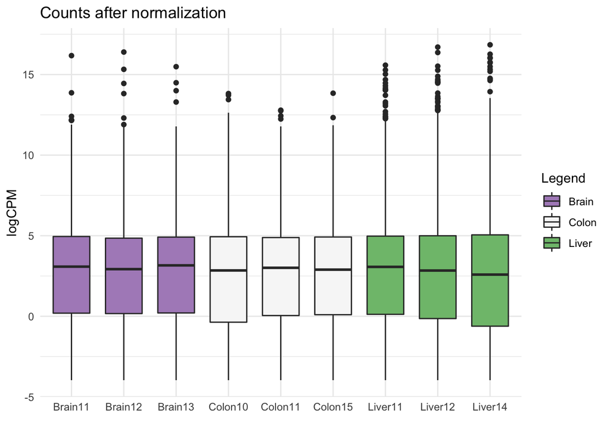

```r
logcpm_after_long <- data.frame(logcpm_after)
#pivot the data frame into a long format

logcpm_after_long$GeneID <- rownames(logcpm_after_long)
names <- colnames(logcpm_after_long)[1: length(colnames(logcpm_after_long)) - 1]

logcpm_after_long  <- logcpm_after_long  %>% pivot_longer(cols= names ,
                    names_to= 'Samples',
                    values_to='counts')
logcpm_after_long$Legend <- ifelse(logcpm_after_long$Samples %in% brain, 'Brain', ifelse(logcpm_after_long$Samples %in% liver, 'Liver', 'Colon'))
logcpm_after_long $Samples <- as.factor(logcpm_after_long $Samples)

ggplot(logcpm_after_long , aes(x= Samples, y= counts, fill = Legend)) +
  geom_boxplot(width = 0.7) + theme_minimal() +
  labs(title="Counts after normalization", x = '', y = "logCPM") +
  scale_fill_brewer(palette = 'PRGn')
```

## DE genes analysis

Design the linear model, no need to set an intercept since there is no base condition to which each sample can be compared to.

```r
design <- model.matrix(~ 0 + group, data = y$samples)
colnames(design) <- levels(y$samples$group)
```

### MDS

MultiDimensional Scaling plot to visualize the data in a 2 dimesional plot. The 2 dimension are the the Leading logFC dimension. MDS plot uses the top 500 genes and compare their logFC to find similiarities between the samples. If the samples cluster toghether than we can assume they represent a similar condition.

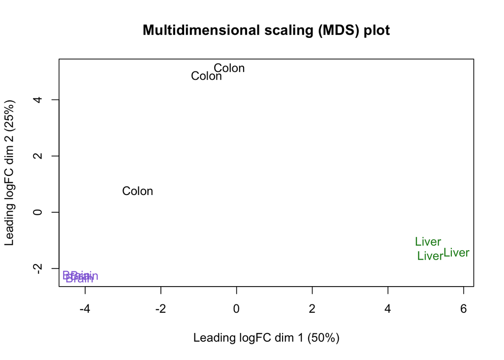

```r
plotMDS(logcpm, labels = group, main = 'Multidimensional scaling (MDS) plot', col=c(rep("mediumpurple",3),rep("forestgreen",3),rep("black",3)))
```

A colon sample is very far from the other two, so I replot the samples using other factors that can account for the variability.

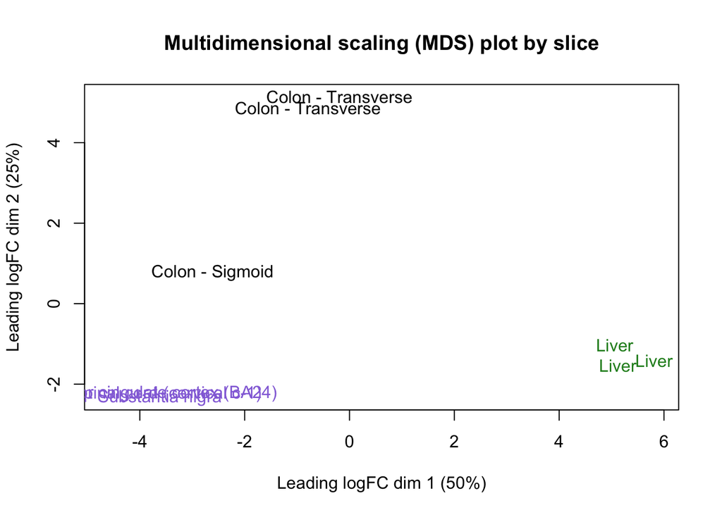

```r
# slice
plotMDS(logcpm, labels=y$samples$slice, main = 'Multidimensional scaling (MDS) plot by slice', col=c(rep("mediumpurple",3),rep("forestgreen",3),rep("black",3)))
```

### BCV

THe plot describes the relationship between average expression and variability. The underlying statistical model is the negative binomial distribution. The variance depends on a key parameter: the dispersion. The plot is to visualize the square root of dispersion (= biological coefficient of variation BCV) with respect to the average logCPM.

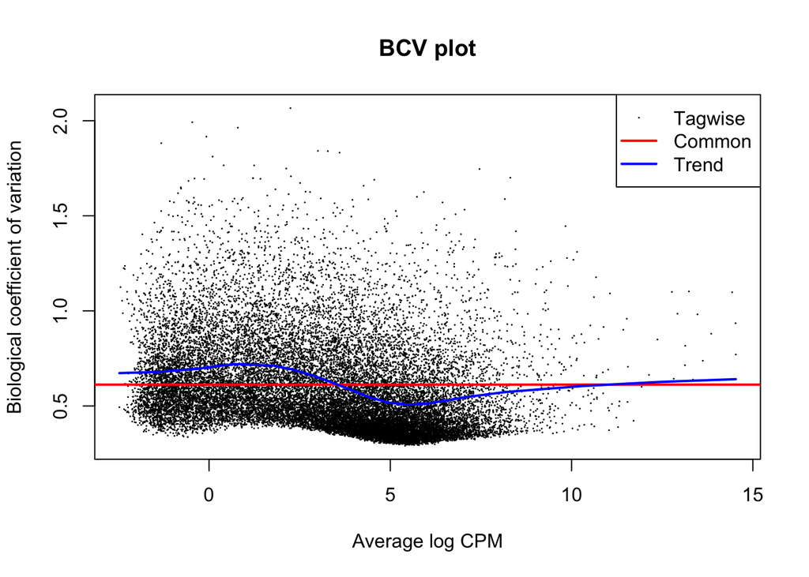

```r
y <- estimateDisp(y, design)
plotBCV(y, main = 'BCV plot')
```

## Differentially Expressed Genes

### GLM

Fit the generalized linear model

```r
fit <- glmQLFit(y, design)

# The order of the group is Brain, Colon, Liver since the order is alphabetical.

# COLON vs BRAIN
qlf.CvsB <- glmQLFTest(fit, contrast=c(-1, 1, 0))

# LIVER vs BRAIN
qlf.LvsB <- glmQLFTest(fit, contrast=c(-1, 0, 1))

# COLON vs LIVER
qlf.CvsL <- glmQLFTest(fit, contrast=c(0, 1, -1))
```

Quick summary for genes UP, DOWN and Not differential expressed for each comparison:

• Colon vs Brain

```r
# different adjusted p.value and FC
#summary(decideTests(qlf.CvsB, p.value=0.01, lfc=0))
#summary(decideTests(qlf.CvsB, p.value=0.01, lfc=1))
# between 0 and 1 the result doesn't change

summary(decideTests(qlf.CvsB, p.value=0.05, lfc=1))
```

```
##        -1*Brain 1*Colon
## Down               2373
## NotSig            19213
## Up                 1767
```

```r
# different adjusted p.value and FC
#summary(decideTests(qlf.CvsL, p.value=0.01, lfc=0))
#summary(decideTests(qlf.CvsL, p.value=0.01, lfc=1)) #FDR < 0.01
summary(decideTests(qlf.CvsL, p.value=0.05, lfc=1))
```

```
##        1*Colon -1*Liver
## Down               1474
## NotSig            20978
## Up                  901
```

• Liver vs Brain

```r
# different adjusted p.value and FC
#summary(decideTests(qlf.LvsB, p.value=0.01, lfc=0))
#summary(decideTests(qlf.LvsB, p.value=0.01, lfc=1))
# between 0 and 1 the result doesn't change

summary(decideTests(qlf.LvsB, p.value=0.05, lfc=1))
```

```
##        -1*Brain 1*Liver
## Down               3843
## NotSig            16310
## Up                 3200
```

Extracting the full table of DE genes sorted by adjusted p-values

```r
resultsCB <- topTags(qlf.CvsB, n = 1000000, adjust.method = 'BH', sort.by = 'PValue', p.value = 1)
resultsLB <- topTags(qlf.LvsB, n = 1000000, adjust.method = 'BH', sort.by = 'PValue', p.value = 1)
resultsCL <- topTags(qlf.CvsL, n = 1000000, adjust.method = 'BH', sort.by = 'PValue', p.value = 1)
```

## DE genes in one condition vs both conditions

Select the genes differentially expressed in one tissue against the other two

### Brain

```r
# brain vs liver
brain_BvsL <- rownames(as.data.frame(resultsLB)[as.data.frame(resultsLB)$logFC < -1
                                                & as.data.frame(resultsLB)$FDR < 0.05
                                                & as.data.frame(resultsLB)$logCPM > 0 ,])

# brain vs colon
brain_BvsC <- rownames(as.data.frame(resultsCB)[as.data.frame(resultsCB)$logFC < -1
                                                & as.data.frame(resultsCB)$FDR < 0.05
                                                & as.data.frame(resultsCB)$logCPM > 0 ,])

# intersect the tables:
brain_vs_livercolon <- intersect(brain_BvsC, brain_BvsL)


# trim the list with the genes that are not interesting
starts = c('LOC', 'LINC', 'MIR', 'SNOR', 'RPL')

for(s in starts) {
  brain_vs_livercolon<- brain_vs_livercolon[which(!startsWith(brain_vs_livercolon, s))]
}
```

### Colon

```r
# colon vs liver
colon_CvsL <- rownames(as.data.frame(resultsCL)[as.data.frame(resultsCL)$logFC > 1
                                                & as.data.frame(resultsCL)$FDR < 0.05
                                                & as.data.frame(resultsCL)$logCPM > 0 ,])

# colon vs brain
colon_CvsB <- rownames(as.data.frame(resultsCB)[as.data.frame(resultsCB)$logFC > 1
                                                & as.data.frame(resultsCB)$FDR < 0.05
                                                & as.data.frame(resultsCB)$logCPM > 0 ,])

# intersect the tables:
colon_vs_brainliver <- intersect(colon_CvsL, colon_CvsB)

# trim the list with the genes that are not interesting
starts = c('LOC', 'LINC', 'MIR', 'SNOR', 'RPL')

for(s in starts) {
  colon_vs_brainliver<- colon_vs_brainliver[which(!startsWith(colon_vs_brainliver, s))]
}
```

### Liver

```r
# liver vs colon
liver_LvsC <- rownames(as.data.frame(resultsCL)[as.data.frame(resultsCL)$logFC < -1
                                                & as.data.frame(resultsCL)$FDR < 0.05
                                                & as.data.frame(resultsCL)$logCPM > 0 ,])
# liver vs brain
liver_LvsB <- rownames(as.data.frame(resultsLB)[as.data.frame(resultsLB)$logFC > 1
                                                & as.data.frame(resultsLB)$FDR < 0.05
                                                & as.data.frame(resultsLB)$logCPM > 0 ,])

# intersect the tables:
liver_vs_braincolon <- intersect(liver_LvsC, liver_LvsB)

# trim the list with the genes that are not interesting
starts = c('LOC', 'LINC', 'MIR', 'SNOR', 'RPL')

for(s in starts) {
  liver_vs_braincolon<- liver_vs_braincolon[which(!startsWith(liver_vs_braincolon, s))]
}
```

Saving the results in a excel file

```r
library(writexl)
write_xlsx(data.frame(brain_vs_livercolon), 'topDEgenesBrain_full.xlsx')
write_xlsx(data.frame(liver_vs_braincolon), 'topDEgenesLiver_full.xlsx')
write_xlsx(data.frame(colon_vs_brainliver), 'topDEgenesColon_full.xlsx')
```

## Functional Enrichment Analysis

With ENRICHER Here you can find the page of enricher:

[Brain_full](https://maayanlab.cloud/Enrichr/enrich?dataset=a959e10af76d840541b6d69ef6575427).

[Colon_full](https://maayanlab.cloud/Enrichr/enrich?dataset=18030bea2e68c60d91ccdf185d3e3fc3).

[Liver_full](https://maayanlab.cloud/Enrichr/enrich?dataset=6f5a5b0ebf89e991d683acf0ac8a9b6e).

### Wide analysis of a single gene

```r
assays(rse_brain)$TPM <- recount::getTPM(rse_brain)
```

```
## Setting options('download.file.method.GEOquery'='auto')
```

```
## Setting options('GEOquery.inmemory.gpl'=FALSE)
```

```r
assays(rse_liver)$TPM <- recount::getTPM(rse_liver)
assays(rse_colon)$TPM <- recount::getTPM(rse_colon)
```

```r
id_PMP2<-  which(rowData(rse_brain)$gene_name == 'PMP2')

id_HJV <- which(rowData(rse_liver)$gene_name ==  'HJV')
id_TRAF5 <- which(rowData(rse_colon)$gene_name ==  'TRAF5')
id_HOXA10 <- which(rowData(rse_colon)$gene_name ==  'HOXA10')
```

```r
temp <- data.frame(cbind(assays(rse_brain)$TPM[id_HJV,],assays(rse_liver)$TPM[id_HJV,], assays(rse_colon)$TPM[id_HJV,]))
colnames(temp) <- c("Brain", "Liver", "Colon")
temp <- melt(temp)
```

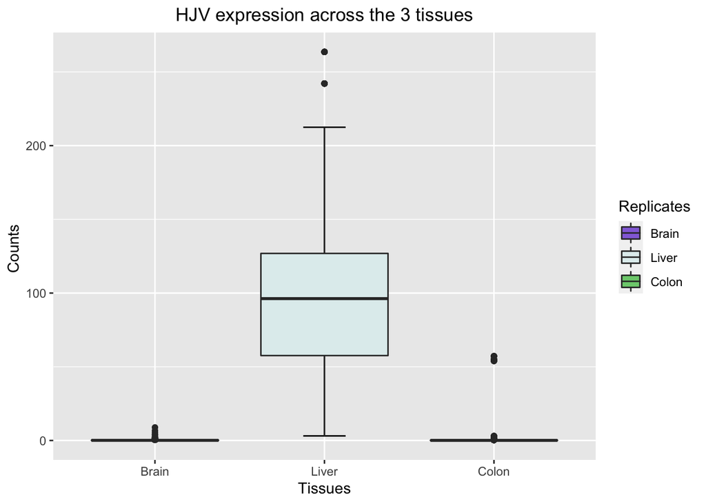

```r
ggplot(temp, aes(x = variable, y = value, fill= variable)) +
  ggtitle("HJV expression across the 3 tissues") +
  theme(plot.title = element_text(hjust = 0.5))+
  stat_boxplot(geom = "errorbar",
               width = 0.25) +
  geom_boxplot() +
  scale_x_discrete(labels = c('Brain','Liver','Colon'))+
  guides(fill = guide_legend(title = "Replicates"), )+
  labs(x= "Tissues", y= "Counts ") + scale_fill_manual(values=c("mediumpurple","azure2", "palegreen3"))
```

```r
temp <- data.frame(cbind(assays(rse_brain)$TPM[id_HOXA10,],assays(rse_liver)$TPM[id_HOXA10,], assays(rse_colon)$TPM[id_HOXA10,]))
colnames(temp) <- c("Brain", "Liver", "Colon")
temp <- melt(temp)
```

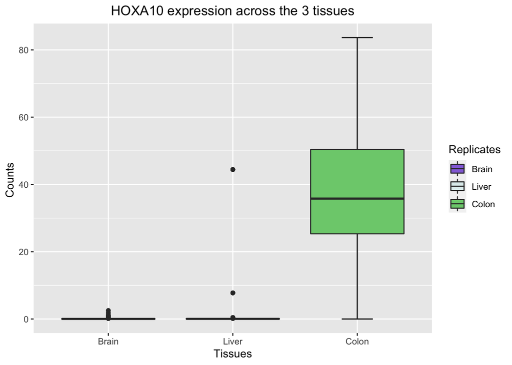

```r
ggplot(temp, aes(x = variable, y = value, fill= variable)) +
  ggtitle("HOXA10 expression across the 3 tissues") +
  theme(plot.title = element_text(hjust = 0.5))+
  stat_boxplot(geom = "errorbar",
               width = 0.25) +
  geom_boxplot() +
  scale_x_discrete(labels = c('Brain','Liver','Colon'))+
  guides(fill = guide_legend(title = "Replicates"), )+
  labs(x= "Tissues", y= "Counts ") + scale_fill_manual(values=c("mediumpurple","azure2", "palegreen3"))
```

```r
temp <- data.frame(cbind(assays(rse_brain)$TPM[id_PMP2,],assays(rse_liver)$TPM[id_PMP2,], assays(rse_colon)$TPM[id_PMP2,]))
colnames(temp) <- c("Brain", "Liver", "Colon")
temp <- melt(temp)
```

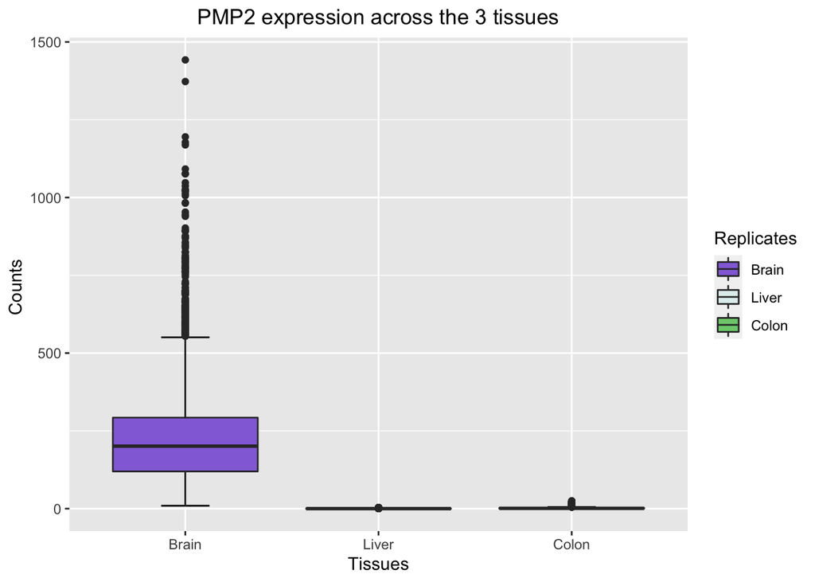

```r
ggplot(temp, aes(x = variable, y = value, fill= variable)) +
  ggtitle("PMP2 expression across the 3 tissues") +
  theme(plot.title = element_text(hjust = 0.5))+
  stat_boxplot(geom = "errorbar",
               width = 0.25) +
  geom_boxplot() +
  scale_x_discrete(labels = c('Brain','Liver','Colon'))+
  guides(fill = guide_legend(title = "Replicates"), )+
  labs(x= "Tissues", y= "Counts ") + scale_fill_manual(values=c("mediumpurple","azure2", "palegreen3"))
```